# Bakery Order Model

## 6.2 Interpretation

Muffins:

```r
- 0.70376
```

```
## [1] -0.70376
```

```r
1-exp(- 0.70376 )
```

```
## [1] 0.5052784
```

Specialty very close to muffins

Multigrain:

```r
- 0.70376 + 0.24049
```

```
## [1] -0.46327
```

```r
1-exp(-0.46327)
```

```
## [1] 0.3707773
```

Pilgram:

- selling out has 13.2% suppression of sales

```r
- 0.70376 + 0.56276
```

```
## [1] -0.141
```

```r
1- exp(0.56276-0.70376)
```

```
## [1] 0.1315107
```

Pie:

No effect. (Never sells out)

Question:

- In your experience, what sells out the most?
- What is most often overstocked/wasted?

## 6.3 Residuals

```r
# update Residuals
bakery_data <- bakery_data %>%
  mutate(
    num_items_pred = predict(
      final_model_nb,      # replace with your model object name
      newdata = bakery_data,
      type = "response"  # IMPORTANT: mean count, not log-scale
    ),
    resid_nb = residuals(final_model_nb, type = "pearson"), # Variance-Standardized
    num_items_residual = num_items - num_items_pred # raw residuals
  ) %>% relocate( num_items, .before = num_items_pred)
```

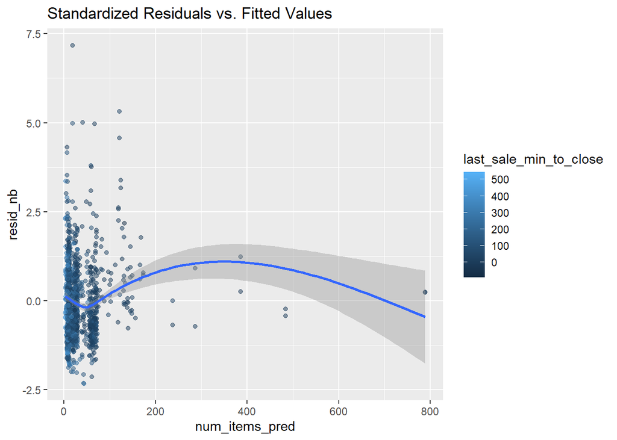

```r
ggplot(bakery_data,
       aes(num_items_pred, resid_nb, color = last_sale_min_to_close)) +
  geom_point(alpha = 0.5) +
  geom_smooth() +
  labs(
      title = "Standardized Residuals vs. Fitted Values"
    )
```

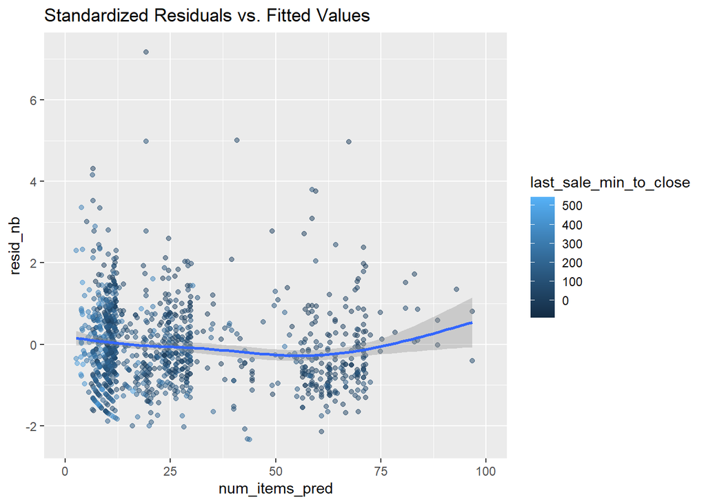

```r
ggplot(bakery_data,
       aes(num_items_pred, resid_nb, color = last_sale_min_to_close)) +
  geom_point(alpha = 0.5) +
  geom_smooth() +
  labs(
      title = "Standardized Residuals vs. Fitted Values"
    ) +
  scale_x_continuous(limits = c(0,100)) +
  scale_y_continuous(breaks = scales::pretty_breaks())
```

Relative Heteroscedasticity up to 100 predicted number of items

The few extreme-demand days (Thanksgiving-class events) that are real, rare, and correctly modeled as part of the stochastic process.

## 6.4 Residuals by Bakery Type

[output not shown]

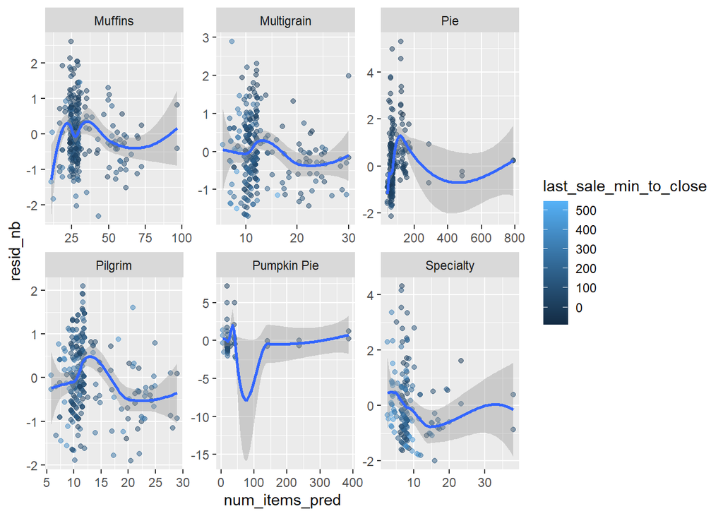

```r
ggplot(bakery_data,
       aes(num_items_pred, resid_nb, color = last_sale_min_to_close)) +
  geom_point(alpha = 0.5) +
  geom_smooth() +
  facet_wrap(~bakery_type, scales = "free")
```

## 6.5 Visualization of residuals by bakery type

```r
plot_data <-  bakery_data %>% pivot_longer(
  cols = c(num_items_pred, num_items),
  names_to = "model",
  values_to = "num_items"
)
```

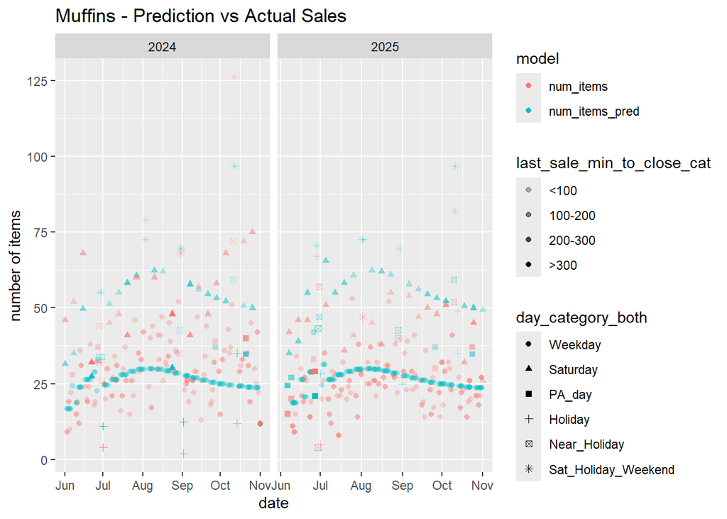

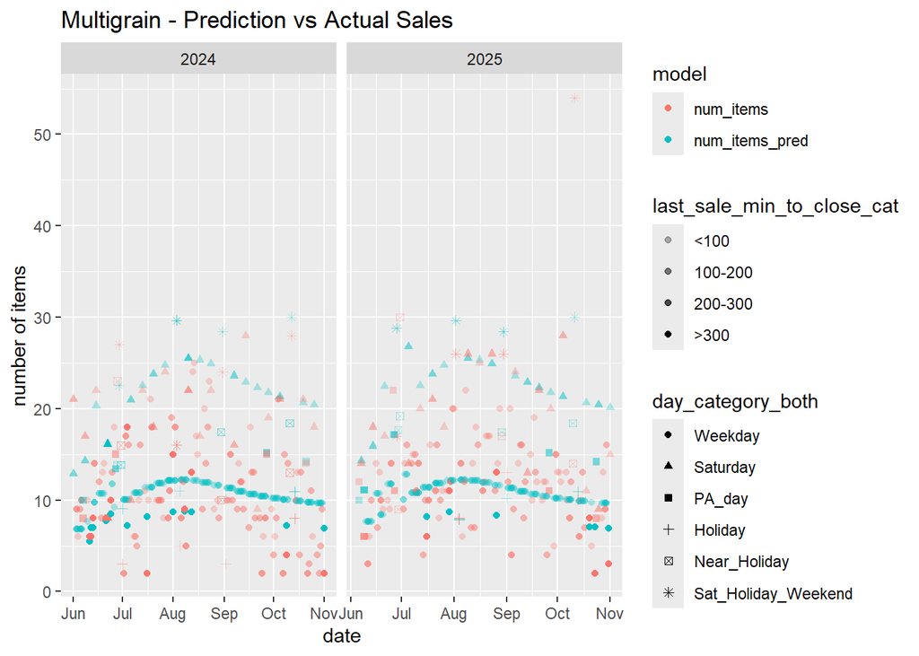

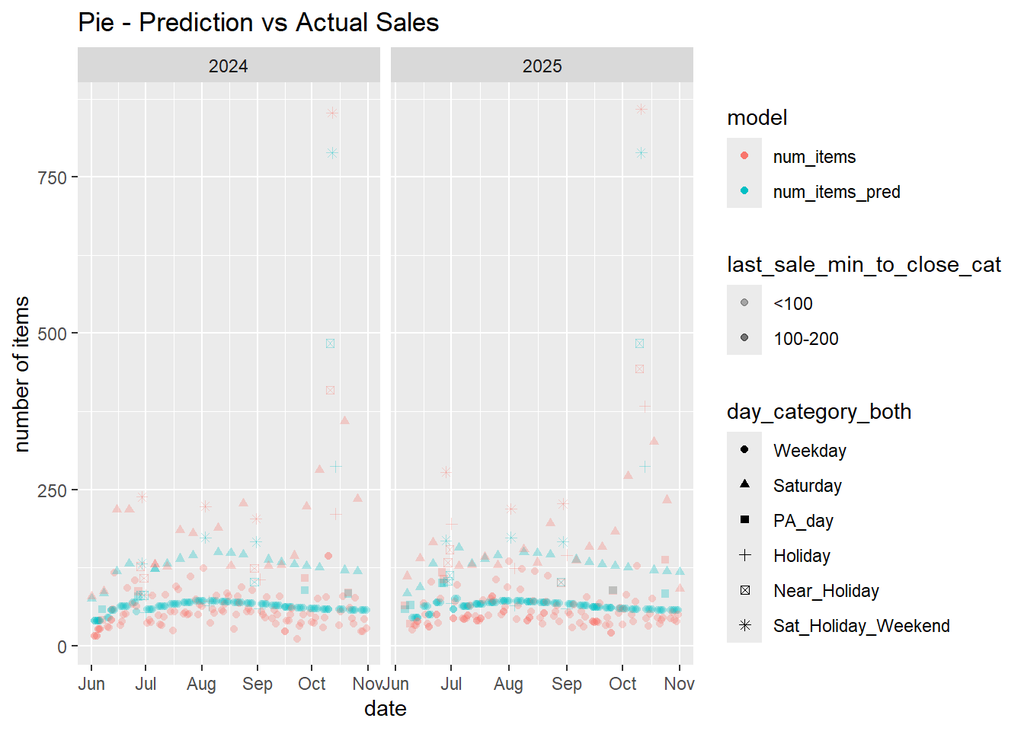

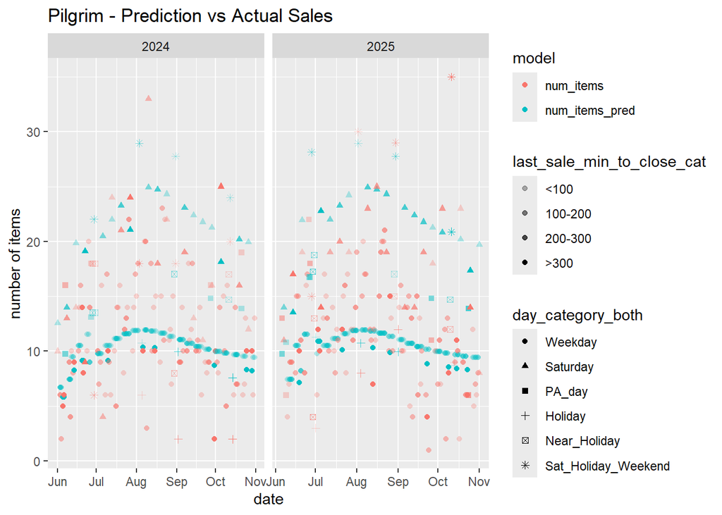

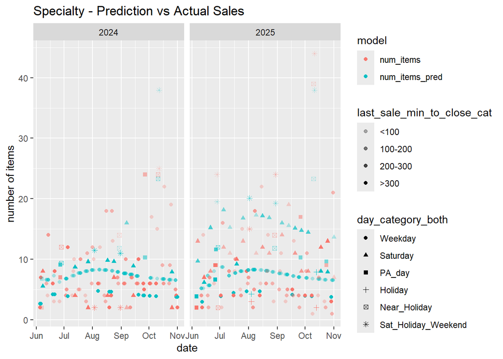

```r
type_names = bakery_data$bakery_type %>% unique()
plots <- vector("list",5)
for (i in 1:5) {
  type = type_names[i]

  plots[[i]] <- plot_data %>% filter(bakery_type == type) %>% ggplot(aes(x = date, y = num_items, color = model,
                                                           shape =  day_category_both,
                                                           alpha = last_sale_min_to_close_cat )) +
    scale_alpha_manual(values = c("<100" = 0.3, "100-200" = 0.5, "200-300" = 0.70, ">300" = 1)) +
    geom_point() +
    facet_wrap(~year, scales = "free_x") +
    labs(
      title = paste0(type," - Prediction vs Actual Sales"),
      y = "number of items",
      x = "date"
    )
  print(plots[[i]])
}
```

Looks decent, but I realize seasonality effects are different for **each product type**, so I need to explore whether including interaction between seasonality and product is feasible in one model, or if I need to use separate models.

See Model A_JOINT and Model_INDEPENDENT